# Assignment 5

Cristina Davila Gonzalez

10/6/2020

# **Grandparents on duty**:

## Initial Linear regression model

```r
o50peopleg_data <-read_csv("O50peopleg.csv")
```

```r
o50peopleg_data <-read_csv("O50peopleg.csv") %>%
   mutate(FDDRSP_label = case_when(
    FDDRSP_label=="Yes" ~ "Care needed",
    FDDRSP_label=="No" ~ "No care needed")) %>%
  mutate(SEX_label = case_when(
    SEX_label=="Male" ~ "Male",
    SEX_label=="Female" ~ "Female")) %>%
  mutate(GCR_label = case_when(
    GCR_label=="Yes" ~ "Responsible",
    GCR_label=="No" ~ "Not Responsible")) %>%
 filter(PINCP != "0")
```

```r
model1 <- lm(AGEP ~ SEX_label+ PINCP + GCR_label + FDDRSP_label,
            data = o50peopleg_data)

summary(model1)
```

```
##
## Call:
## lm(formula = AGEP ~ SEX_label + PINCP + GCR_label + FDDRSP_label,
##     data = o50peopleg_data)
##
## Residuals:
##     Min      1Q  Median      3Q     Max
## -15.763  -6.547  -0.869   5.512  32.162
##
## Coefficients:
##                              Estimate Std. Error t value Pr(>|t|)
## (Intercept)                 6.628e+01  6.979e-01  94.971  < 2e-16 ***
## SEX_labelMale               6.446e-01  4.241e-01   1.520   0.1287
## PINCP                      -2.082e-05  4.432e-06  -4.699 2.82e-06 ***
## GCR_labelResponsible       -2.951e+00  4.382e-01  -6.734 2.23e-11 ***
## FDDRSP_labelNo care needed -1.175e+00  6.938e-01  -1.693   0.0906 .
## ---
## Signif. codes:  0 '***' 0.001 '**' 0.01 '*' 0.05 '.' 0.1 ' ' 1
##
## Residual standard error: 8.553 on 1757 degrees of freedom
## Multiple R-squared:  0.04024,    Adjusted R-squared:  0.03805
## F-statistic: 18.42 on 4 and 1757 DF,  p-value: 7.779e-15
```

## Log transformation - Total person’s income (PINCP)

```r
model2 <- lm(AGEP ~ SEX_label+ log(PINCP) + GCR_label + FDDRSP_label,
            data = o50peopleg_data)
summary(model2)
```

```
##
## Call:
## lm(formula = AGEP ~ SEX_label + log(PINCP) + GCR_label + FDDRSP_label,
##     data = o50peopleg_data)
##
## Residuals:
##     Min      1Q  Median      3Q     Max
## -16.478  -6.583  -0.779   5.399  32.052
##
## Coefficients:
##                            Estimate Std. Error t value Pr(>|t|)
## (Intercept)                 79.4199     2.0657  38.448  < 2e-16 ***
## SEX_labelMale                0.9496     0.4253   2.233   0.0257 *
## log(PINCP)                  -1.4037     0.2006  -6.998 3.68e-12 ***
## GCR_labelResponsible        -2.7989     0.4359  -6.421 1.74e-10 ***
## FDDRSP_labelNo care needed  -1.1388     0.6887  -1.653   0.0984 .
## ---
## Signif. codes:  0 '***' 0.001 '**' 0.01 '*' 0.05 '.' 0.1 ' ' 1
##
## Residual standard error: 8.492 on 1755 degrees of freedom
##   (2 observations deleted due to missingness)
## Multiple R-squared:  0.0546, Adjusted R-squared:  0.05244
## F-statistic: 25.34 on 4 and 1755 DF,  p-value: < 2.2e-16
```

The R-squared value changes, very slightly, from 0.04 to 0.0546, which shows a considerably improvement. Let’s try other options .

## Conversion from continuous to categorical - Income (PINCP)

```r
o50peopleg_data <- o50peopleg_data %>%
  mutate(income_block = case_when(PINCP < 50001 ~ "Under 50,000$",
                               PINCP > 50000 ~ "Over 50,000$"))

model3 <- lm(AGEP ~ SEX_label+ income_block + GCR_label + FDDRSP_label,
            data = o50peopleg_data)

summary(model3)
```

```
##
## Call:
## lm(formula = AGEP ~ SEX_label + income_block + GCR_label + FDDRSP_label,
##     data = o50peopleg_data)
##
## Residuals:
##     Min      1Q  Median      3Q     Max
## -16.045  -6.708  -0.881   5.184  32.011
##
## Coefficients:
##                            Estimate Std. Error t value Pr(>|t|)
## (Intercept)                 63.2236     0.8216  76.948  < 2e-16 ***
## SEX_labelMale                0.8268     0.4268   1.937   0.0529 .
## income_blockUnder 50,000$    2.8213     0.4974   5.673 1.64e-08 ***
## GCR_labelResponsible        -2.8919     0.4372  -6.615 4.92e-11 ***
## FDDRSP_labelNo care needed  -1.1639     0.6918  -1.683   0.0926 .
## ---
## Signif. codes:  0 '***' 0.001 '**' 0.01 '*' 0.05 '.' 0.1 ' ' 1
##
## Residual standard error: 8.529 on 1757 degrees of freedom
## Multiple R-squared:  0.04566,    Adjusted R-squared:  0.04349
## F-statistic: 21.01 on 4 and 1757 DF,  p-value: < 2.2e-16
```

The model fit is better than the initial, even if it is by a margin of 0.005. However, is not as good as the model with the logarithmic transformation. It was still worth the try.

## Adding an interaction term - Gender (SEX_label)

```r
model4 <- lm(AGEP ~ SEX_label+ income_block + GCR_label + FDDRSP_label +
               income_block:SEX_label + GCR_label:SEX_label +
               FDDRSP_label:SEX_label,
            data = o50peopleg_data)

summary(model4)
```

```
##
## Call:
## lm(formula = AGEP ~ SEX_label + income_block + GCR_label + FDDRSP_label +
##     income_block:SEX_label + GCR_label:SEX_label + FDDRSP_label:SEX_label,
##     data = o50peopleg_data)
##
## Residuals:
##     Min      1Q  Median      3Q     Max
## -16.206  -6.675  -0.963   5.296  32.030
##
## Coefficients:
##                                          Estimate Std. Error t value Pr(>|t|)
## (Intercept)                               63.8701     1.0816  59.053  < 2e-16
## SEX_labelMale                             -0.2255     1.5703  -0.144  0.88583
## income_blockUnder 50,000$                  1.9188     0.7358   2.608  0.00919
## GCR_labelResponsible                      -2.7334     0.5664  -4.826 1.52e-06
## FDDRSP_labelNo care needed                -1.0852     0.9141  -1.187  0.23533
## SEX_labelMale:income_blockUnder 50,000$    1.6424     1.0001   1.642  0.10073
## SEX_labelMale:GCR_labelResponsible        -0.3208     0.8919  -0.360  0.71912
## SEX_labelMale:FDDRSP_labelNo care needed  -0.1031     1.3992  -0.074  0.94129
##
## (Intercept)                              ***
## SEX_labelMale
## income_blockUnder 50,000$                **
## GCR_labelResponsible                     ***
## FDDRSP_labelNo care needed
## SEX_labelMale:income_blockUnder 50,000$
## SEX_labelMale:GCR_labelResponsible
## SEX_labelMale:FDDRSP_labelNo care needed
## ---
## Signif. codes:  0 '***' 0.001 '**' 0.01 '*' 0.05 '.' 0.1 ' ' 1
##
## Residual standard error: 8.53 on 1754 degrees of freedom
## Multiple R-squared:  0.04723,    Adjusted R-squared:  0.04343
## F-statistic: 12.42 on 7 and 1754 DF,  p-value: 1.317e-15
```

At the same time, the negative coefficients for both categories regarding grandchildren responsibility and self-care difficulty suggest that most people who are responsible for their grandchildren are not only younger, but also don’t need any sort of assisted care. When it comes to gender, the difference is slightly greater for men than for women.

## Visualizing the results

### Comparison between model results

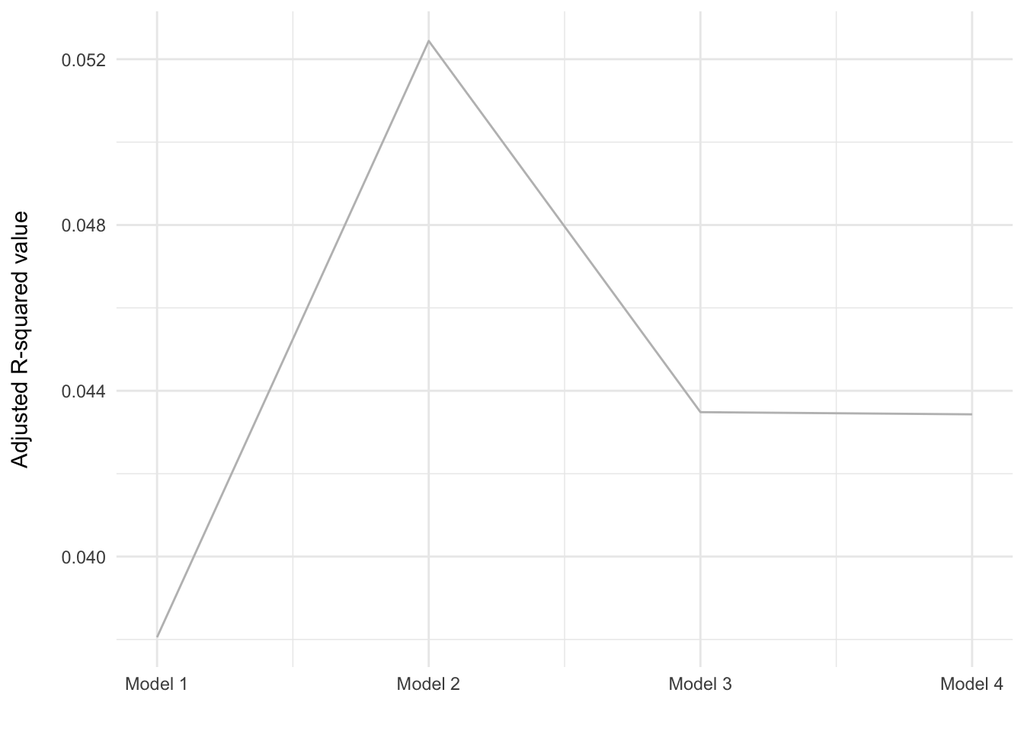

```r
ModelFit <- tibble(model = c(1, 2, 3, 4),
                   R_square = c(summary(model1)$adj.r.squared,
                                summary(model2)$adj.r.squared,
                                summary(model3)$adj.r.squared,
                                summary(model4)$adj.r.squared))

ggplot(ModelFit, aes(x = model, y = R_square)) +
  geom_line(color= "gray") +
  scale_x_continuous(name = "",
                   breaks = breaks <- seq(1, 4, by = 1),
                   labels = paste("Model", breaks)) +
  scale_y_continuous(name = "Adjusted R-squared value\n") +
  theme_minimal()
```

Model 2 is definitely the preferred model.

### Table format for preferred model

```r
coeff_names <- c("Male\n(compared to female)" = "SEX_labelMale",
                 "Total income\n(log-transformed)" =
                   "log(PINCP)",
                 "Grandchildren responsibility\n(compared to not responsible)" =
                   "GCR_labelResponsible",
                 "Self-care difficulty\n(compared to no care needed)" =
                   "FDDRSP_labelNo care needed")

export_summs(model1, model2,
             error_format = "(p = {p.value})",
             error_pos = "same",
             model.names = c("Initial model", "Preferred model"),
             coefs = coeff_names)
```

[output not shown]

### Visualizing preferred regresion model results

[figure not shown]

```r
coeff_desc <- c(" Being male\n(compared to female)" = "SEX_labelMale",
                 "Doubling total income\n(log-transformed)" =
                   "log(PINCP)",
                 "Being responsible for grandchildren\n(compared to not being responsible)" =
                   "GCR_labelResponsible",
                 "Presenting any self-care difficulty\n(compared to no care needed)" =
                   "FDDRSP_labelNo care needed")

plot_coefs(model2,colors = "gray",
           coefs = coeff_desc,
           plot.distributions = TRUE,
           rescale.distributions = TRUE) +
  scale_x_continuous(name = "\nEffect on predicted age (years)")+
  scale_color_manual(values = wes_palette("Moonrise1", n =1))
```

### Predicted relationships between income and age, for both men and women

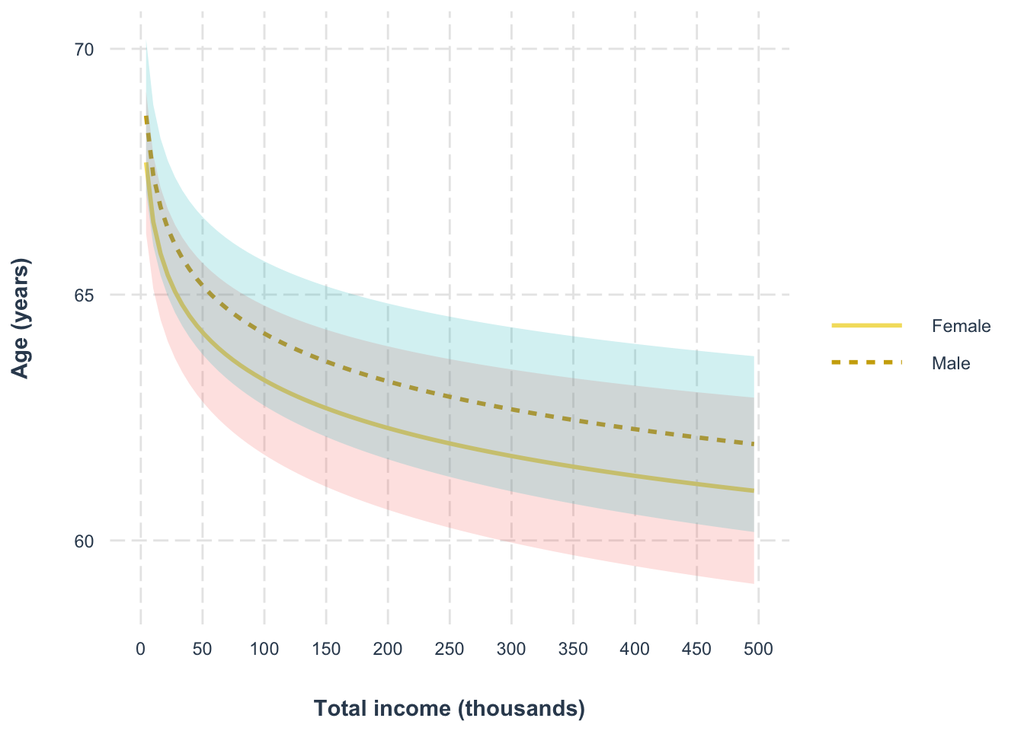

```r
interact_plot(model2, pred = PINCP, modx = SEX_label, interval = TRUE) +
  scale_x_continuous(name = "\nTotal income (thousands)",
                     limits = c(0, 500000),
                     breaks = breaks <- seq(0, 500000, by = 50000),
                     labels = paste(
                                    prettyNum(breaks/1000, big.mark = "'"),
                                    sep = "")) +
  scale_y_continuous(name = "Age (years)\n",
                     breaks = seq(50, 100, by = 5 )) +
  scale_color_manual(name = "",
                      values = wes_palette("Moonrise1", n = 2),
                       labels = c("Female",
                                  "Male")) +
  scale_linetype_discrete(name = "") +
  scale_fill_discrete(name = "")
```

### Predicted relationships between grandchildren responsibility and age, for both men and women

[figure not shown]

```r
cat_plot(model2, pred = GCR_label, modx = SEX_label, interval = TRUE) +
 scale_x_discrete(name = "\nGrandchildren responsibility",
                    labels = c("Responsible", "Not responsible")) +
   scale_y_continuous(name = "Age (years)\n",
                     breaks = seq(50, 100, by = 5 )) +
  scale_color_manual(name = "",
                      values = wes_palette("Moonrise1", n = 2),
                       labels = c("Female",
                                  "Male")) +
  scale_linetype_discrete(name = "") +
  scale_fill_discrete(name = "")
```